# Final Project

Eli Guo, Jijin Xu, TingXuan Tang, Xinyi Zhang

2023-04-23

# 1 Statement of the Research Problem

The objective of our project is to develop a regression model with ARIMA errors that predicts the stock prices of the top 9 constituent NASDAQ stocks (“AAPL”, “MSFT”, “GOOG”, “AMZN”, “TSLA”, “META”, “NVDA”, “PEP”, “COST”) by analyzing the earnings call transcripts of these companies. We selected these stocks based on the article by NASDAQ (https://www.nasdaq.com/articles/the-top-10-constituents-of-the-nasdaq-100-index).

It is worth noting that Alphabet has 2 stocks (GOOG and GOOGL) in the list, but the company only holds 1 earnings call transcript every quarter. Therefore, we selected the class C share as our target stock, leaving the list with 9 stocks. We retrieved the earnings call transcripts data from the FMP API and financial data from Yahoo Finance using Quantmod. The data range covers the period from 2013 to 2022, a total of 10 years. We use the data from 2013 to 2020 (8 years) for training the model and the data from 2021 to 2022 (2 years) for testing.

We performed sentiment analysis and latent semantic analysis (LSA) to extract statistics and dimensions as predictors for our ARIMA model. As the output data is highly dimensional, we used factor analysis to reduce the dimensionality. Finally, we were able to pass the predictors gained from text mining as xreg in the ARIMA function to construct a regression model with ARIMA errors. However, while the model fitted better for the training data, it actually overfits and performs worse on the testing data.

# 2 Earnings Call Data

```r
# install.packages('fmpcloudr')
library(fmpcloudr)

# Set FMP Cloud API token and parameters
fmpc_set_token("104c65e14abb7ee3eb0a01a146a0d538", timeBtwnReq = 0.2, noBulkWarn = TRUE)
# Retrieve a list of all available stock symbols
symbols_available = fmpc_symbols_available()
# Display the first few rows of the symbol list
head(symbols_available)
```

```
## # A tibble: 6 × 6
##   symbol  name                            price exchange exchangeShortName type
##   <chr>   <chr>                           <dbl> <chr>    <chr>             <chr>
## 1 KZMS.ME The Open Joint Stock Company K…   226 MCX      MCX               stock
## 2 NELY.JK PT Pelayaran Nelly Dwi Putri T…   346 Jakarta… JKT               stock
## 3 COAL.JK PT Black Diamond Resources Tbk    145 Jakarta… JKT               stock
## 4 BBRI.JK PT Bank Rakyat Indonesia (Pers…  5250 Jakarta… JKT               stock
## 5 ASLC.JK PT Autopedia Sukses Lestari Tbk    97 Jakarta… JKT               stock
## 6 GGRM.JK PT Gudang Garam Tbk             29000 Jakarta… JKT               stock
```

```r
# Create a list of top 9 constituent NASDAQ stock symbols
symbol = c("AAPL", "MSFT", "GOOG", "AMZN", "TSLA", "META", "NVDA", "PEP", "COST")
# Check whether symbols in the list are available
symbol %in% symbols_available$symbol
```

```
## [1] TRUE TRUE TRUE TRUE TRUE TRUE TRUE TRUE TRUE
```

```r
# Function to get transcripts from FMP Cloud API
get_transcripts = function(symbols, quarters, years) {
    combinations = expand.grid(symbols, quarters, years)
    transcripts = apply(combinations, 1, function(combination) {
        fmpc_earning_call_transcript(combination[1], combination[2], combination[3])
    })
    transcripts = do.call(rbind, transcripts)
    return(transcripts)
}
```

```r
# Fetch earnigns call transcripts data
transcripts = get_transcripts(symbols = symbol, quarter = 1:4, year = 2013:2022)
str(transcripts)
```

```
## tibble [357 × 5] (S3: tbl_df/tbl/data.frame)
##  $ symbol : chr [1:357] "AAPL" "MSFT" "GOOG" "AMZN" ...
##  $ quarter: int [1:357] 1 1 1 1 1 1 1 1 1 2 ...
##  $ year   : int [1:357] 2013 2013 2013 2013 2013 2013 2013 2013 2013 2013 ...
##  $ date   : chr [1:357] "2013-01-24 17:00:00" "2012-10-18 17:00:00" "2013-04-18 17:00:00" "2013-04-25 17:00:00" ...
##  $ content: chr [1:357] "Operator: Good day, everyone, and welcome to this Apple Incorporated First Quarter Fiscal Year 2013 Earnings Re"| __truncated__ "Operator: Welcome to Microsoft’s Fiscal Year 2013 First Quarter Earnings Conference Call. All lines have been p"| __truncated__ "Operator: Good…
```

```r
library(stringr)

# Explore the size of each transcript
mean(nchar(transcripts$content))  # characters
```

```
## [1] 48842.52
```

```r
mean(str_count(transcripts$content, pattern = "\\S+"))  # words
```

```
## [1] 8470.63
```

```r
mean(str_count(transcripts$content, pattern = "[A-Za-z,;'\"\\\\s]+[^.!?]*[.?!]"))  #sentences
```

```
## [1] 516.9524
```

```r
library(tidyr); library(dplyr)
transcripts = transcripts %>%
        # Fill in missing values for symbol, quarter, and year
        complete(symbol, quarter, year) %>%
        # Convert date column to date object
        mutate(date = as.Date(date),
               # Remove newline characters from content
               content = gsub("\n", "", content),
               # Remove non-alphanumeric characters from content
               content = gsub("[^[:alnum:][:space:]]", "", content))
```

```r
transcripts[which(is.na(transcripts$content)), ]  #missing values
```

```
## # A tibble: 3 × 5
##   symbol quarter  year date   content
##   <chr>    <int> <int> <date> <chr>
## 1 NVDA         3  2019 NA     <NA>
## 2 NVDA         3  2022 NA     <NA>
## 3 PEP          2  2021 NA     <NA>
```

```r
write.csv(transcripts, "transcripts.csv")
```

# 3 Financial Data

```r
library(quantmod)
start_date = min(transcripts$date, na.rm = TRUE)
end_date = max(transcripts$date, na.rm = TRUE) + 1

# Download the data for multiple companies using lapply() function
stock_prices = lapply(symbol, function(x) {
    stocks = getSymbols.yahoo(x, from = start_date, to = end_date, periodicity = "daily",
        auto.assign = FALSE)
    # Extract the adjusted stock price data from the daily data frames
    adj_close = data.frame(date = index(stocks), Adjusted = as.numeric(stocks[, paste0(x,
        ".Adjusted")]))
    # Add the company name column to the data frame
    adj_close$symbol = x
    return(adj_close)
})

stock_prices = do.call(rbind, stock_prices)
head(stock_prices)
```

```
##         date Adjusted symbol
## 1 2012-05-11 17.22633   AAPL
## 2 2012-05-14 16.96826   AAPL
## 3 2012-05-15 16.81476   AAPL
## 4 2012-05-16 16.59924   AAPL
## 5 2012-05-17 16.11410   AAPL
## 6 2012-05-18 16.12201   AAPL
```

```r
write.csv(stock_prices, "stock_prices.csv")
```

```r
# Combine stock prices and transcripts data
data = stock_prices %>%
    inner_join(transcripts, by = c("symbol", "date")) %>%
    # Add 'id' column as document id
mutate(id = row_number()) %>%
    select(id, year, quarter, date, symbol, content, Adjusted)
```

```r
write.csv(data, "data_combined.csv")
```

# 4 Sentiment Analysis

```r
library(tidytext)

# Extract the percentage of positive words for each document using 'bing'
# lexicon
pct_positive_words = data %>%
    unnest_tokens(input = content, output = word) %>%
    inner_join(get_sentiments("bing")) %>%
    group_by(id) %>%
    summarize(pct_positive_words = mean(sentiment == "positive")) %>%
    ungroup()
head(pct_positive_words)
```

```
## # A tibble: 6 × 2
##      id pct_positive_words
##   <int>              <dbl>
## 1     1              0.829
## 2     2              0.807
## 3     3              0.812
## 4     4              0.894
## 5     5              0.867
## 6     6              0.886
```

```r
# Extract the sentiment score for each document using 'afinn' lexicon
sentiment_score = data %>%
    select(id, content) %>%
    group_by(id) %>%
    unnest_tokens(output = word, input = content) %>%
    inner_join(get_sentiments("afinn")) %>%
    summarize(sentiment_score = mean(value)) %>%
    ungroup()
head(sentiment_score)
```

```
## # A tibble: 6 × 2
##      id sentiment_score
##   <int>           <dbl>
## 1     1            1.28
## 2     2            1.36
## 3     3            1.59
## 4     4            1.50
## 5     5            1.51
## 6     6            1.62
```

```r
# Combine the percentage of positive words and sentiment score as sentiment
# predictors
sentiment_pred = merge(pct_positive_words, sentiment_score)
head(sentiment_pred)
```

```
##   id pct_positive_words sentiment_score
## 1  1          0.8288043        1.281407
## 2  2          0.8069705        1.363196
## 3  3          0.8118081        1.590769
## 4  4          0.8944724        1.501149
## 5  5          0.8671096        1.506135
## 6  6          0.8857868        1.616408
```

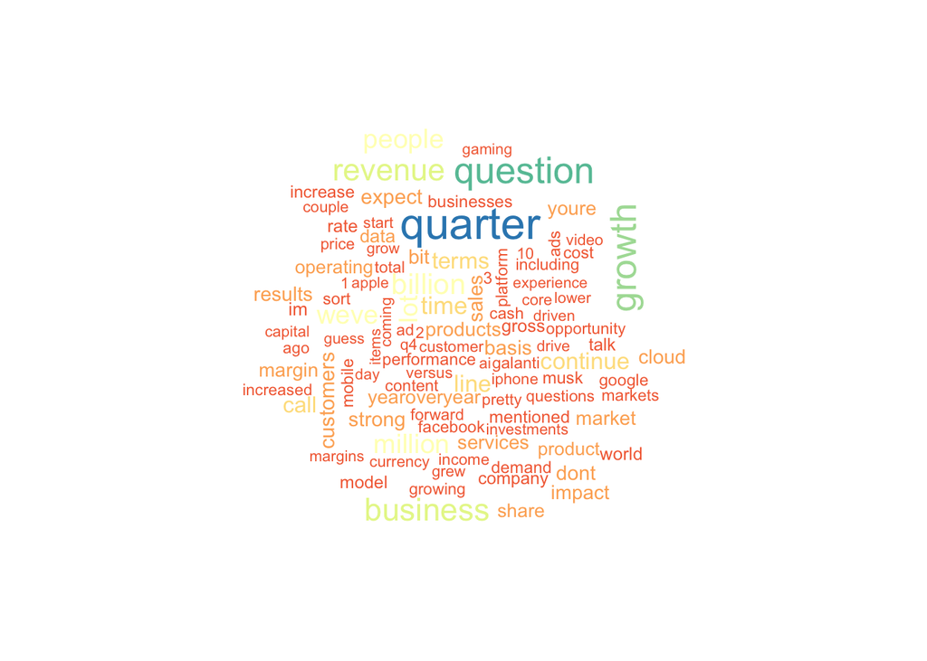

```r
library(wordcloud)

# Prepare the data for the word cloud
wordcloudData = data %>%
    group_by(id) %>%
    unnest_tokens(output = word, input = content) %>%
    ungroup() %>%
    select(id, word) %>%
    anti_join(stop_words) %>%
    group_by(word) %>%
    summarize(freq = n()) %>%
    arrange(desc(freq)) %>%
    ungroup() %>%
    data.frame()

# Create the word cloud
set.seed(617)
wordcloud(words = wordcloudData$word, wordcloudData$freq, scale = c(2, 0.5), max.words = 100,
    colors = brewer.pal(9, "Spectral"))
```

# 5 LSA

```r
library(tm)

# Create a corpus
corpus = Corpus(VectorSource(data$content))
```

```r
# Use tm_map() for data cleaning
corpus = corpus %>%
    # transform text to lower case
tm_map(content_transformer(tolower)) %>%
    # remove any unwanted characters or symbols
tm_map(content_transformer(function(x) iconv(x, to = "UTF-8-MAC", sub = ""))) %>%
    # remove punctuation
tm_map(removePunctuation) %>%
    # remove stopwords
tm_map(removeWords, stopwords("english")) %>%
    tm_map(content_transformer(function(x) gsub("[0-9]", "", x))) %>%
    # remove urls
tm_map(content_transformer(function(x) gsub(pattern = "http[[:alnum:][:punct:]]*",
    replacement = " ", x = x))) %>%
    # remove whitespace
tm_map(stripWhitespace) %>%
    # stem document
tm_map(stemDocument)
```

```r
corpus[[1]]$content
```

```
## [1] "oper good day everyon welcom appl incorpor first quarter fiscal year earn releas confer call today call record time open remark introduct like turn call nanci paxton senior director investor relat pleas go ahead maamnanc paxton thank good afternoon thank everyon join us speak today appl ceo …
```

```r
# Extract cleaned transcripts
transformed_text = sapply(corpus, as.character)
data$transformed_text = transformed_text
str(data)
```

```
## 'data.frame':    356 obs. of  8 variables:
##  $ id              : int  1 2 3 4 5 6 7 8 9 10 ...
##  $ year            : int  2013 2013 2013 2013 2014 2014 2014 2014 2015 2015 ...
##  $ quarter         : int  1 2 3 4 1 2 3 4 1 2 ...
##  $ date            : Date, format: "2013-01-24" "2013-04-23" ...
##  $ symbol          : chr  "AAPL" "AAPL" "AAPL" "AAPL" ...
##  $ content         : chr  "Operator Good day everyone and welcome to this Apple Incorporated First Quarter Fiscal Year 2013 Earnings Relea"| __truncated__ "Operator Please standby we are about to begin Good day ladies and gentlemen and welcome to this Apple Incorpora"| __truncated__ "Operator Ple…
##  $ Adjusted        : num  13.8 12.5 13 16.1 15.9 ...
##  $ transformed_text: chr  "oper good day everyon welcom appl incorpor first quarter fiscal year earn releas confer call today call record "| __truncated__ "oper pleas standbi begin good day ladi gentlemen welcom appl incorpor second quarter fiscal year earn releas co"| __truncated__ "oper pleas s…
```

```r
# Create a dictionary for stem completion
dict = findFreqTerms(DocumentTermMatrix(Corpus(VectorSource(data$content))), lowfreq = 0)
dict_corpus = Corpus(VectorSource(dict))
```

```r
# Create a DocumentTermMatrix
dtm = DocumentTermMatrix(corpus)
inspect(dtm[1, ])
```

```
## <<DocumentTermMatrix (documents: 1, terms: 26913)>>
## Non-/sparse entries: 1128/25785
## Sparsity           : 96%
## Maximal term length: 27
## Weighting          : term frequency (tf)
## Sample             :
##     Terms
## Docs billion can ipad iphon million product quarter sale thank year
##    1      48  39   58    75      41      55     125   34    35   57
```

```r
# Remove sparse terms
xdtm = removeSparseTerms(dtm, sparse = 0.95)

# Complete stems
xdtm = as.data.frame(as.matrix(xdtm))
colnames(xdtm) = stemCompletion(x = colnames(xdtm), dictionary = dict_corpus, type = "prevalent")
colnames(xdtm) = make.names(colnames(xdtm))
```

```r
# Browse tokens
sort(colSums(xdtm), decreasing = T)[1:20]
```

```
##     think      year   quarter      just  question      will     thank    busier
##     16398     14284     13313     11923     11003     10295     10119      9464
##       see      well    growth       can      like   product   revenue continual
##      9235      8905      8886      8641      8641      8087      7966      7827
##       now      that       one       new
##      7558      7336      7264      6762
```

```r
library(lsa)
# Apply Latent Semantic Analysis to the DocumentTermMatrix
clusters = lsa(xdtm)
# Get the top keywords from each cluster and convert to a data frame
lsa_pred = as.data.frame(clusters$tk)
dim(lsa_pred)
```

```
## [1] 356  63
```

```r
# Reset column names
colnames(lsa_pred) = paste0("dim", 1:63)
lsa_pred = lsa_pred %>%
    # Add 'id' column
mutate(id = row_number()) %>%
    select(id, everything())
head(lsa_pred)
```

```
##   id        dim1         dim2        dim3        dim4       dim5       dim6
## 1  1 -0.05662985 -0.012629323 -0.06415249 -0.03699281 -0.1772641 0.04477643
## 2  2 -0.05358694  0.008805393 -0.05773064 -0.02925561 -0.1494273 0.04581339
## 3  3 -0.04683292 -0.002108809 -0.05054853 -0.03113295 -0.1411928 0.04331421
## 4  4 -0.05333677 -0.006167042 -0.04878139 -0.03164094 -0.1526035 0.03846470
## 5  5 -0.05050973 -0.006453736 -0.06663937 -0.01580529 -0.1547087 0.05379498
## 6  6 -0.05039373  0.004926087 -0.03137240 -0.01344053 -0.1371223 0.03455450
##            dim7         dim8        dim9        dim10       dim11       dim12
## 1 -0.0194929211  0.001969608 -0.04158169  0.005180473 -0.05880752  0.02505866
## 2 -0.0144238881  0.017592118 -0.03723639  0.008625312 -0.08065836  0.02280960
## 3 -0.0101704883  0.003682879 -0.03005502 -0.022095543 -0.05798331  0.01438645
## 4 -0.0168110626 -0.008866324 -0.02663138 -0.020448546 -0.04424234  0.01504937
## 5 -0.0200643808  0.017749214 -0.04325700  0.042241335 -0.09049179 -0.04341053
## 6 -0.0002379012  0.028997772 -0.02390658 -0.009021679 -0.03336188  0.02651137
##          dim13        dim14       dim15      dim16        dim17     dim18
```

[output cut: 62 more lines]

# 6 BERT

```r
# Import necessary libraries
library(tidyverse)  # For data manipulation
library(tensorflow)  # For deep learning
library(reticulate)  # For Python integration
library(LiblineaR)  # For linear models
library(tidymodels)  # For modeling

# Set up virtual environment for reticulate
use_virtualenv("~/myenv")

# Install 'transformers' package using pip
py_install("transformers", pip = T)
```

```
## Using virtual environment '/Users/tangmao/myenv' ...
```

```r
# Import necessary Python packages using reticulate
transformer = reticulate::import("transformers")  # For NLP models
tf = reticulate::import("tensorflow")  # For deep learning models
builtins = import_builtins()  # For built-in Python functions

# Create tokenizer object
tokenizer = transformer$AutoTokenizer$from_pretrained("bert-base-uncased")

# Get text data from 'data' data frame
texts = data %>%
    select(transformed_text) %>%
    pull()

# Encode texts using tokenizer object
texts_encodings = tokenizer(texts, truncation = TRUE, padding = TRUE, max_length = 250L)

# Create BERT model object
BERT = transformer$TFBertModel$from_pretrained("bert-base-uncased")

# Initialize features matrix
features = matrix(NA, nrow = length(texts), ncol = 768)

# Iterate through texts, encode with tokenizer and reshape with BERT model
for (i in 1:length(texts)) {
    encodings_i = tokenizer(texts[i], truncation = TRUE, padding = TRUE, max_length = 250L,
        return_tensors = "tf")
    features[i, ] = py_to_r(array_reshape(BERT(encodings_i)[[1]][[0]][[0]], c(1,
        768)))
}

# Set column names of features matrix
colnames(features) = str_c("V", rep(1:768))

features = as.data.frame(features)

# Display first six rows of features data frame
head(features)
```

```
##           V1           V2        V3          V4         V5         V6
## 1 -0.3860000  0.079470292 0.2485653 -0.09220287 -0.1625042 -0.1986446
## 2 -0.3433641 -0.096338816 0.2612026 -0.17086563 -0.2163144 -0.3130707
## 3 -0.3839040  0.084182486 0.2915750 -0.05000017 -0.2091367 -0.2200620
## 4 -0.4447575 -0.008164022 0.2611237 -0.02256423 -0.1436542 -0.2406597
## 5 -0.3229542  0.085825205 0.2777095 -0.13620655 -0.2286169 -0.2178336
## 6 -0.3175025 -0.028285969 0.3816711 -0.04221199 -0.1479344 -0.3002149
##           V7        V8          V9        V10         V11        V12       V13
## 1 0.03220056 0.1661670 -0.17172253 -0.2635286 -0.05261488 0.15196915 0.1714749
## 2 0.12522997 0.1588804 -0.08159101 -0.4028967 -0.01769636 0.20293300 0.1532166
## 3 0.02021100 0.2031720 -0.23324078 -0.2862164 -0.13921061 0.09430164 0.1448356
## 4 0.05289414 0.2013581 -0.21390422 -0.3533685 -0.05538173 0.17631489 0.1068205
## 5 0.09457179 0.2693715 -0.15296882 -0.3661296 -0.02087984 0.05112385 0.2069461
## 6 0.09797017 0.1827912 -0.13899899 -0.3745885 -0.07348707 0.21983871 0.1252787
##          V14        V15         V16          V17       V18       V19
```

[output cut: 811 more lines]

```r
data1 = cbind(data$Adjusted, features)

names(data1)[names(data1) == "data$Adjusted"] <- "Adjusted"

set.seed(617)
split = caret::createDataPartition(data1$Adjusted, p = 0.7, list = FALSE)
train_set = data1[split, ]
test_set = data1[-split, ]

reg = lm(Adjusted ~ ., train_set)
summary(reg)
```

```
##
## Call:
## lm(formula = Adjusted ~ ., data = train_set)
##
## Residuals:
##          1          3          5          6          9         10         11
## -9.484e-14  2.908e-15  1.901e-14  9.869e-14 -1.670e-14 -7.340e-14  4.360e-14
##         12         13         14         15         17         20         21
##  1.309e-13 -8.488e-14 -7.046e-14  5.481e-14  2.329e-14  6.849e-14 -4.364e-14
##         22         23         24         26         28         29         31
##  1.130e-14 -4.479e-14 -4.690e-15 -3.225e-14 -9.823e-14  7.383e-14  6.271e-14
##         32         33         35         36         37         38         39
##  4.514e-14 -6.030e-14  3.234e-14 -1.715e-13  3.674e-14  4.260e-14 -4.801e-14
##         40         41         43         47         48         50         51
##  7.621e-15  9.041e-14 -6.366e-14 -4.375e-14  3.489e-14 -6.474e-14  1.013e-13
##         52         53         54         56         57         59         60
##  1.897e-14 -9.794e-14  7.618e-14 -1.485e-13 -1.634e-14  9.124e-14 -2.036e-13
##         61         62         67         68         69         71         72
## -4.286e-14  8.888e-14  7.720e-14  2.866e-14  5.604e-14 -4.045e-14  1.307e-15
##         73         74         77         78         79         80         81
##  5.067e-15  3.003e-14 -3.514e-14 -8.952e-14  1.408e-13  1.196e-14  3.741e-14
##         82         84         85         86         88         91         95
##  7.525e-14 -3.825e-14 -8.078e-14  1.218e-13 -6.580e-14  3.564e-14 -5.508e-14
##         98         99        100        104        105        107        108
##  5.521e-14 -5.459e-14  2.547e-14 -1.131e-13  1.637e-14  4.974e-14  2.214e-15
##        109        110        111        112        113        115        116
##  6.406e-14 -1.108e-13  1.521e-14  4.870e-14 -2.826e-14 -6.862e-14  2.143e-14
##        117        118        119        121        123        124        125
## -4.813e-14  2.790e-14  8.612e-14 -7.650e-13 -1.129e-13  4.016e-14  5.733e-13
##        126        128        129        130        131        132        133
##  5.093e-14  1.106e-13 -5.902e-14  3.963e-14 -7.629e-15 -1.055e-13  9.230e-14
##        136        137        138        139        140        141        142
##  6.614e-14  3.308e-13 -5.995e-13 -3.544e-13 -2.511e-14 -3.472e-12  2.137e-12
##        144        145        148        149        150        151        152
## -5.092e-13  2.092e-13 -1.136e-14 -1.039e-13  9.066e-17 -6.660e-13  1.508e+01
##        154        155        156        157        158        159        160
## -2.536e-13  1.011e-12 -1.508e+01  3.391e-12 -1.063e-12 -1.401e-13 -3.224e-14
##        161        163        165        166        167        168        169
## -1.748e-14  3.742e-14 -1.257e-13  1.035e-13  3.565e-14  7.338e-15  4.988e-14
##        170        172        174        176        177        178        180
```

[output cut: 798 more lines]

```
## V758                NA         NA      NA       NA
## V759                NA         NA      NA       NA
## V760                NA         NA      NA       NA
## V761                NA         NA      NA       NA
## V762                NA         NA      NA       NA
## V763                NA         NA      NA       NA
## V764                NA         NA      NA       NA
## V765                NA         NA      NA       NA
## V766                NA         NA      NA       NA
## V767                NA         NA      NA       NA
## V768                NA         NA      NA       NA
##
## Residual standard error: 21.32 on 1 degrees of freedom
## Multiple R-squared:  0.9998, Adjusted R-squared:  0.946
## F-statistic: 18.58 on 250 and 1 DF,  p-value: 0.1833
```

```r
pred_train = predict(reg)
rmse_train = sqrt(mean((train_set$Adjusted - pred_train)^2))
rmse_train
```

```
## [1] 1.343188
```

```r
pred_test = predict(reg, newdata = test_set)
rmse_test = sqrt(mean((test_set$Adjusted - pred_test)^2))
rmse_test
```

```
## [1] 22191.37
```

# 7 Regression with Arima errors

```r
# Add predictors from sentiment analysis and lsa to data
data = data %>%
    inner_join(sentiment_pred, by = "id") %>%
    inner_join(lsa_pred, by = "id") %>%
    select(-c(content, transformed_text))
head(data)
```

```
##   id year quarter       date symbol Adjusted pct_positive_words sentiment_score
## 1  1 2013       1 2013-01-24   AAPL 13.81550          0.8288043        1.281407
## 2  2 2013       2 2013-04-23   AAPL 12.52739          0.8069705        1.363196
## 3  3 2013       3 2013-07-23   AAPL 13.00961          0.8118081        1.590769
## 4  4 2013       4 2013-10-29   AAPL 16.14881          0.8944724        1.501149
## 5  5 2014       1 2014-01-28   AAPL 15.92306          0.8671096        1.506135
## 6  6 2014       2 2014-04-24   AAPL 17.95607          0.8857868        1.616408
##          dim1         dim2        dim3        dim4       dim5       dim6
## 1 -0.05662985 -0.012629323 -0.06415249 -0.03699281 -0.1772641 0.04477643
## 2 -0.05358694  0.008805393 -0.05773064 -0.02925561 -0.1494273 0.04581339
## 3 -0.04683292 -0.002108809 -0.05054853 -0.03113295 -0.1411928 0.04331421
## 4 -0.05333677 -0.006167042 -0.04878139 -0.03164094 -0.1526035 0.03846470
## 5 -0.05050973 -0.006453736 -0.06663937 -0.01580529 -0.1547087 0.05379498
## 6 -0.05039373  0.004926087 -0.03137240 -0.01344053 -0.1371223 0.03455450
##            dim7         dim8        dim9        dim10       dim11       dim12
```

[output cut: 69 more lines]

```r
# Check missing values
sum(is.na(data))
```

```
## [1] 0
```

```r
# Calculate the mean of the predictors and stock prices for each quarter
data = data %>%
    group_by(year, quarter) %>%
    select(-c(id, date, symbol)) %>%
    summarise_all(mean) %>%
    arrange(year, quarter)
# Scale predictors
data[, 4:68] = scale(data[, 4:68])
data
```

```
## # A tibble: 40 × 68
## # Groups:   year [10]
##     year quarter Adjusted pct_positive_words sentiment_score    dim1   dim2
##    <int>   <int>    <dbl>              <dbl>           <dbl>   <dbl>  <dbl>
##  1  2013       1     27.6           0.617            -0.845   0.321  -1.52
##  2  2013       2     33.5           1.00              0.422  -0.0477 -1.94
##  3  2013       3     33.0           0.566             0.431   0.0122 -1.38
##  4  2013       4     35.9           0.439            -0.0654 -0.311  -0.877
##  5  2014       1     36.5           0.606             0.233  -0.527  -0.892
##  6  2014       2     39.3          -0.416             0.513  -0.396  -0.858
##  7  2014       3     40.0           0.776             0.964  -0.294  -1.17
##  8  2014       4     43.1          -0.228             0.0346 -0.561  -0.803
##  9  2015       1     45.9           1.13              1.06   -0.932  -0.834
## 10  2015       2     50.0           0.000958          0.0515 -1.14   -0.543
## # ℹ 30 more rows
## # ℹ 61 more variables: dim3 <dbl>, dim4 <dbl>, dim5 <dbl>, dim6 <dbl>,
## #   dim7 <dbl>, dim8 <dbl>, dim9 <dbl>, dim10 <dbl>, dim11 <dbl>, dim12 <dbl>,
## #   dim13 <dbl>, dim14 <dbl>, dim15 <dbl>, dim16 <dbl>, dim17 <dbl>,
## #   dim18 <dbl>, dim19 <dbl>, dim20 <dbl>, dim21 <dbl>, dim22 <dbl>,
## #   dim23 <dbl>, dim24 <dbl>, dim25 <dbl>, dim26 <dbl>, dim27 <dbl>,
## #   dim28 <dbl>, dim29 <dbl>, dim30 <dbl>, dim31 <dbl>, dim32 <dbl>, …
```

# 8 Factor Analysis

```r
factors = data[, 4:68]
library(psych)
# Examine suitability for factor analysis
KMO(r = cor(factors))
```

```
## Error in solve.default(r) :
##   system is computationally singular: reciprocal condition number = 1.49362e-19
```

```
## Kaiser-Meyer-Olkin factor adequacy
## Call: KMO(r = cor(factors))
## Overall MSA =  0.5
## MSA for each item =
## pct_positive_words    sentiment_score               dim1               dim2
##                0.5                0.5                0.5                0.5
##               dim3               dim4               dim5               dim6
##                0.5                0.5                0.5                0.5
##               dim7               dim8               dim9              dim10
##                0.5                0.5                0.5                0.5
##              dim11              dim12              dim13              dim14
##                0.5                0.5                0.5                0.5
##              dim15              dim16              dim17              dim18
##                0.5                0.5                0.5                0.5
##              dim19              dim20              dim21              dim22
##                0.5                0.5                0.5                0.5
##              dim23              dim24              dim25              dim26
##                0.5                0.5                0.5                0.5
##              dim27              dim28              dim29              dim30
##                0.5                0.5                0.5                0.5
##              dim31              dim32              dim33              dim34
##                0.5                0.5                0.5                0.5
##              dim35              dim36              dim37              dim38
##                0.5                0.5                0.5                0.5
##              dim39              dim40              dim41              dim42
##                0.5                0.5                0.5                0.5
##              dim43              dim44              dim45              dim46
##                0.5                0.5                0.5                0.5
##              dim47              dim48              dim49              dim50
##                0.5                0.5                0.5                0.5
##              dim51              dim52              dim53              dim54
##                0.5                0.5                0.5                0.5
##              dim55              dim56              dim57              dim58
##                0.5                0.5                0.5                0.5
##              dim59              dim60              dim61              dim62
##                0.5                0.5                0.5                0.5
##              dim63
##                0.5
```

```r
# Calculate eigen values
data.frame(factor = 1:ncol(factors), eigen = eigen(cor(factors))$values)
```

```
##    factor         eigen
## 1       1  8.282627e+00
## 2       2  7.211041e+00
## 3       3  5.075368e+00
## 4       4  4.889895e+00
## 5       5  4.098530e+00
## 6       6  3.818649e+00
## 7       7  3.014776e+00
## 8       8  2.926555e+00
## 9       9  2.447286e+00
## 10     10  2.197532e+00
## 11     11  2.031899e+00
## 12     12  1.873044e+00
## 13     13  1.703323e+00
## 14     14  1.648248e+00
```

[output cut: 51 more lines]

```r
# Examine total variance explained
result = fa(r = factors, nfactors = 19, fm = "pa", rotate = "varimax")
result$Vaccounted
```

```
##                             PA1       PA14        PA5        PA2        PA3
## SS loadings           7.5749491 4.51798526 3.77216311 3.70515706 3.27645572
## Proportion Var        0.1165377 0.06950747 0.05803328 0.05700242 0.05040701
## Cumulative Var        0.1165377 0.18604514 0.24407842 0.30108084 0.35148785
## Proportion Explained  0.1405225 0.08381290 0.06997719 0.06873417 0.06078135
## Cumulative Proportion 0.1405225 0.22433537 0.29431256 0.36304673 0.42382809
##                              PA4       PA10        PA7        PA9        PA6
## SS loadings           3.17015982 2.78897220 2.55479919 2.38873368 2.27207912
## Proportion Var        0.04877169 0.04290726 0.03930460 0.03674975 0.03495506
## Cumulative Var        0.40025954 0.44316680 0.48247141 0.51922116 0.55417622
## Proportion Explained  0.05880946 0.05173807 0.04739394 0.04431327 0.04214922
## Cumulative Proportion 0.48263755 0.53437562 0.58176956 0.62608283 0.66823205
##                             PA19       PA18       PA15       PA12       PA13
## SS loadings           2.19796288 2.17717839 2.15466784 2.13808820 2.00835487
## Proportion Var        0.03381481 0.03349505 0.03314874 0.03289366 0.03089777
## Cumulative Var        0.58799103 0.62148608 0.65463482 0.68752848 0.71842625
## Proportion Explained  0.04077429 0.04038872 0.03997113 0.03966356 0.03725688
## Cumulative Proportion 0.70900634 0.74939506 0.78936619 0.82902974 0.86628663
##                             PA16        PA8       PA17       PA11
## SS loadings           1.90725970 1.82769442 1.82158003 1.65136637
## Proportion Var        0.02934246 0.02811838 0.02802431 0.02540564
## Cumulative Var        0.74776871 0.77588708 0.80391139 0.82931703
## Proportion Explained  0.03538147 0.03390546 0.03379203 0.03063441
## Cumulative Proportion 0.90166810 0.93557356 0.96936559 1.00000000
```

```r
# Extract weighted average of variables as factors
pred = as.data.frame(result$scores)
pred
```

```
##            PA1        PA14         PA5          PA2         PA3         PA4
## 1  -13.8348599   7.4036472  -2.6082065  0.404969521  5.43833424 -3.88755016
## 2  -13.2058047   5.3154553   0.4497074  1.686178334  5.44509892 -1.29831389
## 3  -17.0424868   6.4745738  -1.9909934  2.433118418  1.07038484  3.56436479
## 4  -14.6398410   3.1264972  -6.2735188 -0.188897497  5.23680801  1.34545330
## 5  -10.6589945   3.0694554  -2.8836307  1.221056610  5.82655530  2.85336794
## 6   -9.0366245   3.5440980   3.0057595  1.454964152  3.53442770  0.86613554
## 7  -10.7005333   1.1728313   1.8971449  4.858403989  1.75366394  5.56571754
## 8  -10.4764913  -3.0490548  -3.2444712 -0.819004706 -0.26664859  9.64672299
## 9   -3.9210705   0.8021554   5.7984163  4.970449523 -2.80540070  3.29870299
## 10  -6.6840793  -1.1641426   2.2497391  0.769109488 -2.36519580  0.33138669
## 11  -3.4764183  -0.1856814   3.7118644  2.969486910 -7.77207020 -1.03956701
## 12  -6.7851408  -6.4194449  -4.6385833 -1.636950126 -7.09378976  2.26848393
## 13  -3.6493718  -6.4398250   0.7639688 -2.263220076 -4.44661164 -0.98744243
## 14  -1.6768322  -6.9854295   5.2676574  1.108353248 -3.21641480 -0.81157205
```

[output cut: 149 more lines]

```r
# Combine extracted factors with data
data = data %>%
    select(year, quarter, Adjusted) %>%
    cbind(pred)
data
```

```
## # A tibble: 40 × 22
## # Groups:   year [10]
##     year quarter Adjusted    PA1   PA14    PA5    PA2    PA3    PA4   PA10
##    <int>   <int>    <dbl>  <dbl>  <dbl>  <dbl>  <dbl>  <dbl>  <dbl>  <dbl>
##  1  2013       1     27.6 -13.8   7.40  -2.61   0.405  5.44  -3.89  -3.69
##  2  2013       2     33.5 -13.2   5.32   0.450  1.69   5.45  -1.30  -3.56
##  3  2013       3     33.0 -17.0   6.47  -1.99   2.43   1.07   3.56   0.893
##  4  2013       4     35.9 -14.6   3.13  -6.27  -0.189  5.24   1.35  -0.448
##  5  2014       1     36.5 -10.7   3.07  -2.88   1.22   5.83   2.85   0.544
##  6  2014       2     39.3  -9.04  3.54   3.01   1.45   3.53   0.866  1.61
##  7  2014       3     40.0 -10.7   1.17   1.90   4.86   1.75   5.57   2.63
##  8  2014       4     43.1 -10.5  -3.05  -3.24  -0.819 -0.267  9.65   1.67
##  9  2015       1     45.9  -3.92  0.802  5.80   4.97  -2.81   3.30   1.86
## 10  2015       2     50.0  -6.68 -1.16   2.25   0.769 -2.37   0.331  1.28
## # ℹ 30 more rows
## # ℹ 12 more variables: PA7 <dbl>, PA9 <dbl>, PA6 <dbl>, PA19 <dbl>, PA18 <dbl>,
## #   PA15 <dbl>, PA12 <dbl>, PA13 <dbl>, PA16 <dbl>, PA8 <dbl>, PA17 <dbl>,
## #   PA11 <dbl>
```

# 9 Arima

```r
# Split data into train and test
train = data %>%
    filter(year < 2021)
test = data %>%
    filter(year >= 2021)
```

```r
# Create a time series object for stock prices in the train data
train_y = ts(data = train$Adjusted, start = 2013, frequency = 4)
train_y
```

```
##           Qtr1      Qtr2      Qtr3      Qtr4
## 2013  27.60484  33.50299  32.96114  35.94973
## 2014  36.48373  39.29832  39.95237  43.12880
## 2015  45.91535  49.96771  52.01219  51.57996
## 2016  55.49884  57.21902  56.82212  59.80230
## 2017  65.54221  72.21924  76.08771  80.09282
## 2018  82.00287  88.52484  85.36709  93.56874
## 2019  96.72006 101.99889 111.17306 119.51140
## 2020 119.84826 146.37053 154.40456 184.84478
```

```r
# Create a time series object for stock prices in the test data
test_y = ts(data = test$Adjusted, start = 2021, frequency = 4)
test_y
```

```
##          Qtr1     Qtr2     Qtr3     Qtr4
## 2021 197.0560 211.2114 220.5393 233.4883
## 2022 230.4653 218.6439 202.7168 203.9465
```

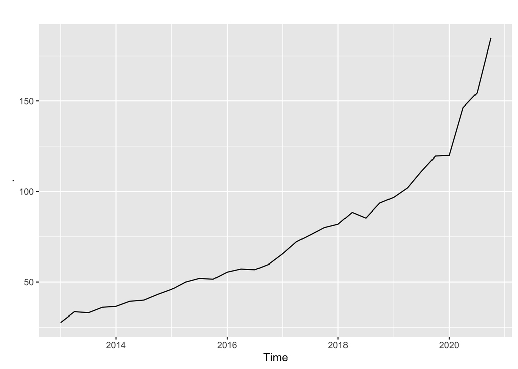

```r
library(forecast)
train_y %>%
    autoplot()  #errors when kniting
```

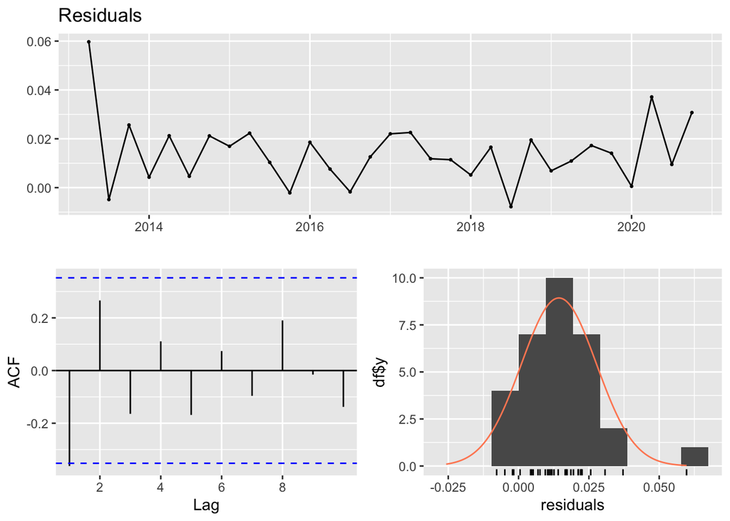

```
##
##  Ljung-Box test
##
## data:  Residuals
## Q* = 9.7707, df = 6, p-value = 0.1346
##
## Model df: 0.   Total lags used: 6
```

```r
train_y %>%
    BoxCox(lambda = BoxCox.lambda(train_y)) %>%
    diff() %>%
    # autoplot() %>% Box.test(type = 'Ljung-Box') %>%
checkresiduals()  #errors when kniting
```

```r
# Create a time series object for predictors in the train data
train_x = ts(data = as.matrix(scale(train[, 4:22])), start = 2013, frequency = 4)
# Create a time series object for predictors in the test data
test_x = ts(data = as.matrix(scale(test[, 4:22])), start = 2021, frequency = 4)
```

```r
library(forecast)
# Construct regression model with ARIMA errors
model = Arima(y = train_y, xreg = train_x, order = c(1, 1, 0), lambda = BoxCox.lambda(train_y))
model
```

```
## Series: train_y
## Regression with ARIMA(1,1,0) errors
## Box Cox transformation: lambda= -0.3445471
##
## Coefficients:
##          ar1     PA1    PA14      PA5     PA2      PA3    PA4     PA10     PA7
##       0.9793  0.0151  0.0012  -0.0041  0.0007  -0.0123  4e-04  -0.0078  0.0017
## s.e.  0.0280  0.0104  0.0035   0.0032  0.0023   0.0033  2e-03   0.0021  0.0021
##           PA9     PA6    PA19    PA18    PA15     PA12     PA13     PA16
##       -0.0037  0.0063  0.0025  0.0007  0.0037  -0.0046  -0.0001  -0.0045
## s.e.   0.0019  0.0028  0.0023  0.0019  0.0019   0.0020   0.0016   0.0012
##          PA8     PA17     PA11
##       0.0011  -0.0094  -0.0055
## s.e.  0.0011   0.0027   0.0014
##
## sigma^2 = 9.619e-05:  log likelihood = 113.89
## AIC=-185.79   AICc=-83.12   BIC=-155.68
```

```r
y = ts(data = data$Adjusted, start = 2013, frequency = 4)
y
```

```
##           Qtr1      Qtr2      Qtr3      Qtr4
## 2013  27.60484  33.50299  32.96114  35.94973
## 2014  36.48373  39.29832  39.95237  43.12880
## 2015  45.91535  49.96771  52.01219  51.57996
## 2016  55.49884  57.21902  56.82212  59.80230
## 2017  65.54221  72.21924  76.08771  80.09282
## 2018  82.00287  88.52484  85.36709  93.56874
## 2019  96.72006 101.99889 111.17306 119.51140
## 2020 119.84826 146.37053 154.40456 184.84478
## 2021 197.05604 211.21139 220.53925 233.48830
## 2022 230.46531 218.64393 202.71679 203.94647
```

```r
model_forecast = forecast(model, h = 8, xreg = test_x)
accuracy(model_forecast, y)
```

```
##                        ME       RMSE        MAE          MPE      MAPE
## Training set    0.2410381   1.626442   1.286231   0.01888275  1.903696
## Test set     -119.6981582 180.475906 131.061169 -56.86406361 62.630449
##                    MASE      ACF1 Theil's U
## Training set 0.07574827 0.3363794        NA
## Test set     7.71840795 0.6120420  17.50045
```

```r
# Implement a normal arima model for comparison
model1 = Arima(y = train_y, order = c(1, 1, 0), lambda = BoxCox.lambda(train_y))
model_forecast1 = forecast(model1, h = 8)
accuracy(model_forecast1, y)
```

```
##                    ME      RMSE      MAE      MPE     MAPE      MASE       ACF1
## Training set 2.972145  7.596783 4.510343 3.213342 5.416553 0.2656215 -0.4499038
## Test set     3.354761 11.429738 9.828488 1.295107 4.493895 0.5788158  0.5443748
##              Theil's U
## Training set        NA
## Test set      1.065288
```